# Partial data analysis on some aspects of forest structure and species composition change along different habitats in a dry forest facing slash-and-burn disturbance

## Models to answer the first question:

1 - How the (a) total aboveground basal area, (b) basal area of primary roots (i.e., below ground) and (c) number of primary roots change among the different habitats?

### Question 1a

```r
model_abtot<-glm(log(ABtot)~habitats, data=dados.parcela) #Gaussian family is the default one for continuous data.

#We are going to use the shapiro.test function to analyze the normality of the residuals
shapiro.test(residuals(model_abtot))
```

```
##
##  Shapiro-Wilk normality test
##
## data:  residuals(model_abtot)
## W = 0.94892, p-value = 0.1861
```

```r
#assess the results
Anova(model_abtot) #There are differences between the habitats, but let's check a pairwise comparison
```

```
## Analysis of Deviance Table (Type II tests)
##
## Response: log(ABtot)
##          LR Chisq Df Pr(>Chisq)
## habitats   34.552  2  3.141e-08 ***
## ---
## Signif. codes:  0 '***' 0.001 '**' 0.01 '*' 0.05 '.' 0.1 ' ' 1
```

```r
abtot.tukey<-glht(model_abtot, mcp(habitats="Tukey"))
summary(abtot.tukey) #We can see differences between the recently abandoned fields and regenerating stands and also old-growth
```

```
##
##   Simultaneous Tests for General Linear Hypotheses
##
## Multiple Comparisons of Means: Tukey Contrasts
##
##
## Fit: glm(formula = log(ABtot) ~ habitats, data = dados.parcela)
##
## Linear Hypotheses:
##                                                      Estimate Std. Error
## Regenerating stands - Recently abandoned fields == 0  1.31545    0.27096
## Old-growth stands - Recently abandoned fields == 0    1.33132    0.25547
## Old-growth stands - Regenerating stands == 0          0.01587    0.27096
##                                                      z value Pr(>|z|)
## Regenerating stands - Recently abandoned fields == 0   4.855   <1e-05 ***
## Old-growth stands - Recently abandoned fields == 0     5.211   <1e-05 ***
## Old-growth stands - Regenerating stands == 0           0.059    0.998
## ---
## Signif. codes:  0 '***' 0.001 '**' 0.01 '*' 0.05 '.' 0.1 ' ' 1
## (Adjusted p values reported -- single-step method)
```

```r
rsq(model_abtot, adj=T) #r²adjusted (more precise) = 0.54
```

```
## [1] 0.5466152
```

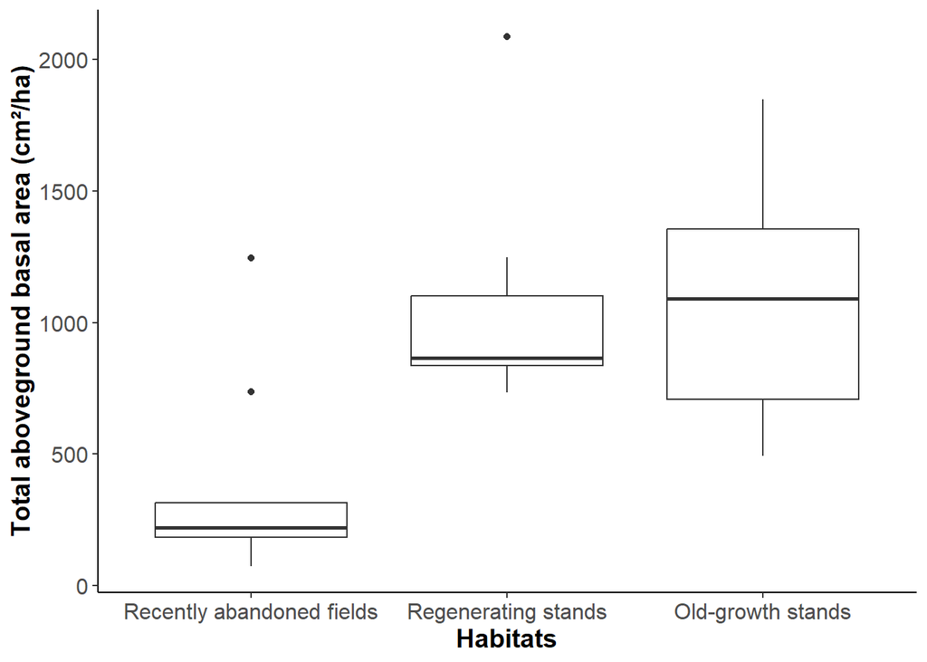

```r
#Let's quickly visualize the data using a boxplot:
ab_tot<-ggplot(dados.parcela)+
  aes(x = habitats, y = ABtot) +
  geom_boxplot() +
  scale_fill_hue(direction = 1) +
  labs(x = "Habitats", y = "Total aboveground basal area (cm²/ha)") +
  theme_classic()+
  theme(axis.text=element_text(size=12),
        axis.title=element_text(size=14,face="bold"))
ab_tot
```

### Question 1b

- Now, let’s check the (b) basal area of primary roots across the habitats

```r
model_abroots<-glm(AB_primary_roots~habitats, family=Gamma, data=dados.parcela) #Here, we used the Gamma family to better adjust our data distribution to the model

#We are going to use the shapiro.test function to analyze the normality of the residuals
shapiro.test(residuals(model_abroots))
```

```
##
##  Shapiro-Wilk normality test
##
## data:  residuals(model_abroots)
## W = 0.91655, p-value = 0.02853
```

```r
#assess the results
Anova(model_abroots)
```

```
## Analysis of Deviance Table (Type II tests)
##
## Response: AB_primary_roots
##          LR Chisq Df Pr(>Chisq)
## habitats   9.3469  2    0.00934 **
## ---
## Signif. codes:  0 '***' 0.001 '**' 0.01 '*' 0.05 '.' 0.1 ' ' 1
```

```r
#There are differences between the habitats, but let's check a pairwise comparison
abroots.tukey<-glht(model_abroots, mcp(habitats="Tukey"))
summary(abroots.tukey) #We can see differences between the recently abandoned fields and regenerating stands
```

```
##
##   Simultaneous Tests for General Linear Hypotheses
##
## Multiple Comparisons of Means: Tukey Contrasts
##
##
## Fit: glm(formula = AB_primary_roots ~ habitats, family = Gamma, data = dados.parcela)
##
## Linear Hypotheses:
##                                                        Estimate Std. Error
## Regenerating stands - Recently abandoned fields == 0 -0.0018218  0.0006866
## Old-growth stands - Recently abandoned fields == 0   -0.0015911  0.0006924
## Old-growth stands - Regenerating stands == 0          0.0002307  0.0004307
##                                                      z value Pr(>|z|)
## Regenerating stands - Recently abandoned fields == 0  -2.653   0.0207 *
## Old-growth stands - Recently abandoned fields == 0    -2.298   0.0537 .
## Old-growth stands - Regenerating stands == 0           0.536   0.8504
## ---
## Signif. codes:  0 '***' 0.001 '**' 0.01 '*' 0.05 '.' 0.1 ' ' 1
## (Adjusted p values reported -- single-step method)
```

```r
rsq(model_abroots, adj=T) #r²adjusted (more precise) = 0.18
```

```
## [1] 0.1889757
```

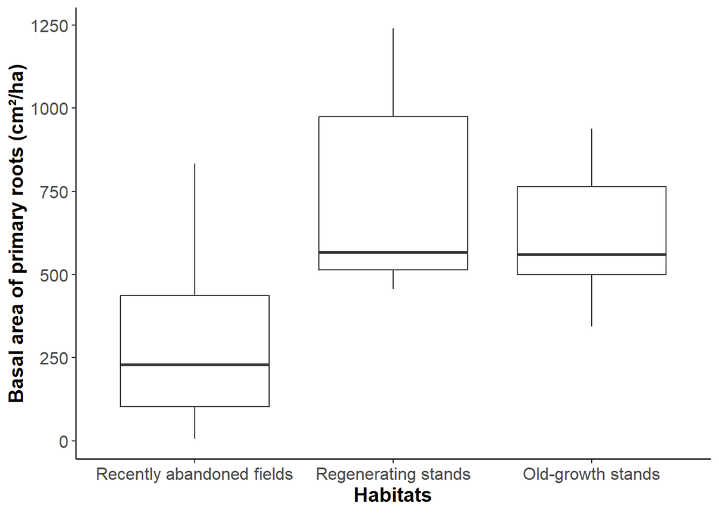

```r
#Let's quickly visualize the data using a boxplot:
ab_prim_roots<-ggplot(dados.parcela)+
  aes(x = habitats, y = AB_primary_roots) +
  geom_boxplot() +
  scale_fill_hue(direction = 1) +
  labs(x = "Habitats", y = "Basal area of primary roots (cm²/ha)") +
  theme_classic()+
  theme(axis.text=element_text(size=12),
        axis.title=element_text(size=14,face="bold"))
ab_prim_roots
```

### Question 1c

- Finally, let’s check (c) the differences on the number of primary roots (num_prim_roots) across the habitats (parcela). The number of primary roots is a count data, so we use the poisson family and need to check for the overdispersion of the data (performance package, check_overdispersion function).

```r
library(performance)
model_primroots<-glm(n_prim_roots~habitats, family=poisson(link="log"), data=dados.parcela)
summary(model_primroots)
```

```
##
## Call:
## glm(formula = n_prim_roots ~ habitats, family = poisson(link = "log"),
##     data = dados.parcela)
##
## Deviance Residuals:
##    Min      1Q  Median      3Q     Max
## -9.874  -4.891  -1.502   1.793  22.854
##
## Coefficients:
##             Estimate Std. Error z value Pr(>|z|)
## (Intercept)  4.87031    0.01741  279.81   <2e-16 ***
## habitats.L   0.65572    0.03234   20.27   <2e-16 ***
## habitats.Q  -0.50569    0.02778  -18.20   <2e-16 ***
## ---
## Signif. codes:  0 '***' 0.001 '**' 0.01 '*' 0.05 '.' 0.1 ' ' 1
##
## (Dispersion parameter for poisson family taken to be 1)
##
##     Null deviance: 1913.4  on 27  degrees of freedom
## Residual deviance: 1217.1  on 25  degrees of freedom
## AIC: 1401.9
##
## Number of Fisher Scoring iterations: 5
```

```r
#Checking for overdispersion
check_overdispersion(model_primroots) #we have a high dispersion ratio
```

```
## # Overdispersion test
##
##        dispersion ratio =   63.862
##   Pearson's Chi-Squared = 1596.551
##                 p-value =  < 0.001
```

```r
#In this case, we can change the function to use the negative binomial family (glm.nb) to better adjust our model
model_primroots<-glm.nb(n_prim_roots~habitats,link = "log", data=dados.parcela)
summary(model_primroots)
```

```
##
## Call:
## glm.nb(formula = n_prim_roots ~ habitats, data = dados.parcela,
##     link = "log", init.theta = 1.925293828)
##
## Deviance Residuals:
##     Min       1Q   Median       3Q      Max
## -2.4204  -0.7445  -0.1575   0.2503   2.9634
##
## Coefficients:
##             Estimate Std. Error z value Pr(>|z|)
## (Intercept)   4.8703     0.1381  35.278  < 2e-16 ***
## habitats.L    0.6557     0.2302   2.849  0.00439 **
## habitats.Q   -0.5057     0.2477  -2.041  0.04122 *
## ---
## Signif. codes:  0 '***' 0.001 '**' 0.01 '*' 0.05 '.' 0.1 ' ' 1
##
## (Dispersion parameter for Negative Binomial(1.9253) family taken to be 1)
##
##     Null deviance: 41.542  on 27  degrees of freedom
## Residual deviance: 30.608  on 25  degrees of freedom
## AIC: 329.78
##
## Number of Fisher Scoring iterations: 1
##
##
##               Theta:  1.925
##           Std. Err.:  0.498
##
##  2 x log-likelihood:  -321.779
```

```r
check_overdispersion(model_primroots) #our dispersion ration substantially reduced, but we can notice a huge outlier
```

```
## # Overdispersion test
##
##        dispersion ratio =  1.569
##   Pearson's Chi-Squared = 39.219
##                 p-value =  0.035
```

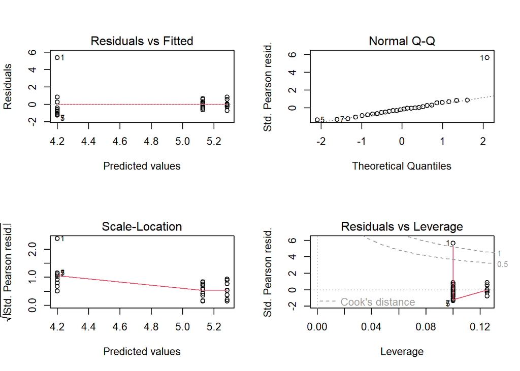

```r
#Visualize the plotted fitted valued vs residuals
par(mfrow=(c(2,2)))
plot(model_primroots)
```

```r
#assess the results
Anova(model_primroots) #X²=10.93, df=2, p=0.004
```

```
## Analysis of Deviance Table (Type II tests)
##
## Response: n_prim_roots
##          LR Chisq Df Pr(>Chisq)
## habitats   10.934  2   0.004223 **
## ---
## Signif. codes:  0 '***' 0.001 '**' 0.01 '*' 0.05 '.' 0.1 ' ' 1
```

```r
#There are differences between the habitats, but let's check a pairwise comparison
nroots.tukey<-glht(model_primroots, mcp(habitats="Tukey"))
summary(nroots.tukey) #Recently abandoned fields have lower number of primary roots than the other 2 habitats
```

```
##
##   Simultaneous Tests for General Linear Hypotheses
##
## Multiple Comparisons of Means: Tukey Contrasts
##
##
## Fit: glm.nb(formula = n_prim_roots ~ habitats, data = dados.parcela,
##     link = "log", init.theta = 1.925293828)
##
## Linear Hypotheses:
##                                                      Estimate Std. Error
## Regenerating stands - Recently abandoned fields == 0   1.0830     0.3450
## Old-growth stands - Recently abandoned fields == 0     0.9273     0.3255
## Old-growth stands - Regenerating stands == 0          -0.1557     0.3436
##                                                      z value Pr(>|z|)
## Regenerating stands - Recently abandoned fields == 0   3.139  0.00476 **
## Old-growth stands - Recently abandoned fields == 0     2.849  0.01239 *
## Old-growth stands - Regenerating stands == 0          -0.453  0.89301
## ---
## Signif. codes:  0 '***' 0.001 '**' 0.01 '*' 0.05 '.' 0.1 ' ' 1
## (Adjusted p values reported -- single-step method)
```

```r
rsq(model_primroots, adj=T) #r²adj=0.14
```

```
## [1] 0.1416198
```

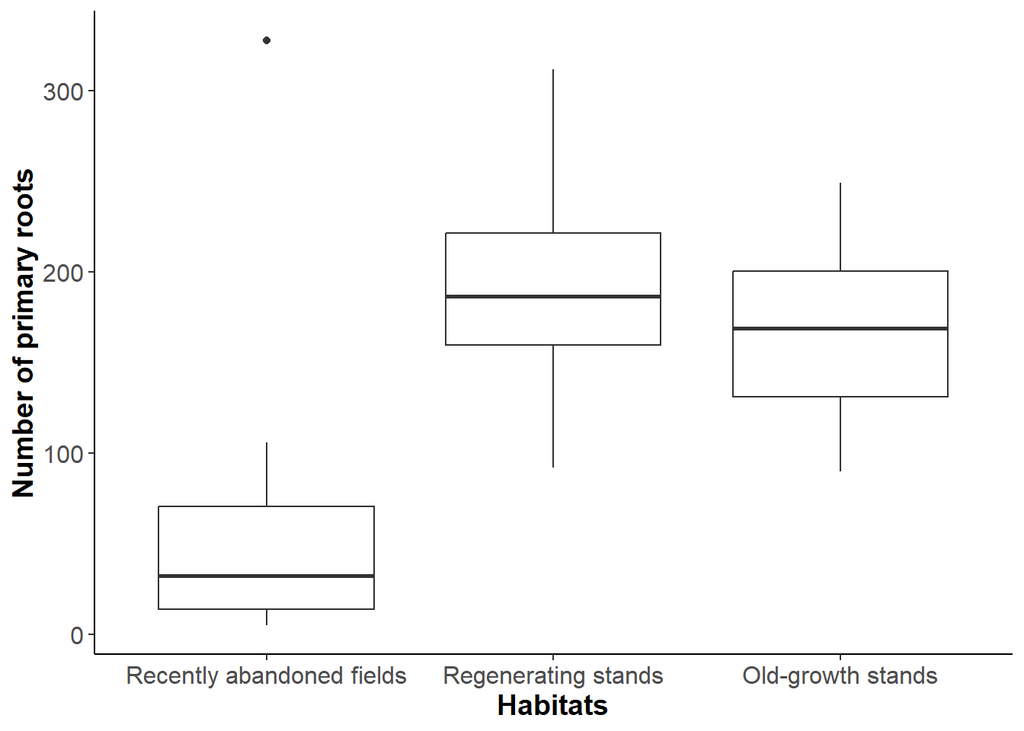

```r
#Let's quickly visualize the data using a boxplot:
prim_roots<-ggplot(dados.parcela)+
  aes(x = habitats, y = n_prim_roots) +
  geom_boxplot() +
  scale_fill_hue(direction = 1) +
  labs(x = "Habitats", y = "Number of primary roots") +
  theme_classic()+
  theme(axis.text=element_text(size=12),
        axis.title=element_text(size=14, face="bold"))
prim_roots
```

Now, let’s put together all the plots using the ggpubr package (ggarrange function):

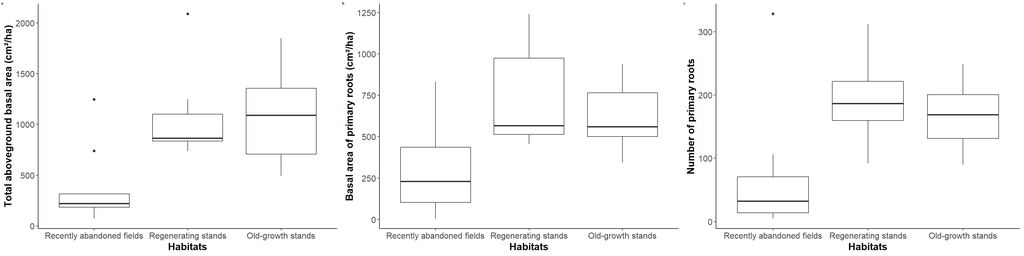

```r
library("ggpubr")

plots<-ggarrange(ab_tot, ab_prim_roots, prim_roots, labels = c("a", "b", "c"),
                font.label = list(size = 5, color = "black", face = "bold", family = NULL),
                                ncol = 3, nrow = 1)

plots
```